# Chronos

Learning the Language of Time Series

Montevideo Applied Data Science, AI and Big Data. Paper Reading Club III

## Contexto

- Modelos de series de tiempo, desde un enfoque estadístico clásico. ARIMA, SARIMA, ETS, etc.
- The Makridakis Competitions luego de M4 fuerte uso de modelos de deep learning.
- Metodologías clásicas muy manuales y dependientes de la experiencia.
- Aumento de recursos computacionales y de datos.
- Resurgimiento de modelos de deep learning, como RNN, LSTM, etc.
- Gran éxito de los LLM y su arquitectura Transformer.

## Entonces…

- ¿Es lo mismo predecir la siguiente palabra en un texto que predecir el valor de una serie de tiempo?
- ¿Es lo mismo transformar la serie y luego incluir en un modelo de LLM directamente?

## Forecasting problem

$$p(\mathbb{Z}_{t+1:t+h} | \mathbb{Z}_{1:t},X_{1:t+h}, \theta)$$

### Diferentes enfoques

- Modelo local univariado: $p(\mathbb{z}_{t+1:t+h} | \mathbb{z}_{i, 1:t}, X_{1:t+h}; \theta_{i})$ con $\theta_{i} = \Psi(z_{i,1:t},X_{i,1:t+h})$.
  - Lo que se haga en la $i$ no afecta a las demás.
- Modelo global univariado: $p(\mathbb{z}_{t+1:t+h} | \mathbb{z}_{1:t}, X_{1:t+h}; \theta)$ con $\theta_{i} = \Psi(z_{i,1:t},X_{i,1:t+h},\Phi)$
  - Se pueden permitir compartir parámetros entre las series de las covariables dado por $\Phi$, la predicción sigue siendo univariada.
- Modelo multivariado: $p(\mathbb{Z}_{t+1:t+h} | \mathbb{Z}_{1:t}, X_{1:t+h}; \theta)$ con $\theta_{i} = \Psi(Z_{i,1:t},X_{i,1:t+h},\Phi)$
  - Para predicciones puntuales puede ser algo simular a un VARMA.

## Supuestos y Modelos (Clásico)

| Supuesto | ARIMA | GARCH | ETS |
| --- | --- | --- | --- |
| Estacionariedad | ✓ | ✗ | ✗ |
| Homocedasticidad | ✓ | ✗ | ✓ |
| Independencia de errores | ✓ | ✓ | ✓ |
| Normalidad de errores | ✓ | ✗ | ✗ |
| Heterocedasticidad condicional | ✗ | ✓ | ✗ |
| Autocorrelación de errores | ✓ | ✓ | ✗ |
| Descomposición en componentes | ✗ | ✗ | ✓ |

Además de hiperparámetros que deben ser ajustados manualmente.

## Time Series Tokenization

Dado una serie $X_{1:C+H} = [x_1, x_2, \ldots, x_C, x_{C+1}, \ldots, x_{C+H}]$ un modelo de lenguaje opera sobre un vocabulario **finito** mientras que una serie de tiempo puede ser cualquier valor real, por esto es necesario reescalar y “cuantizar” la serie en un numero fijo de valores o intervalos.

#### Escalado

Existen diferentes forma de escalar datos y sabemos que la elección de uno u otro puede afectar el entrenamiento de un modelo, en este articulo se menciona que la forma de hacerlo es la siguiente:

$$\hat{x_{i}} = C\frac{x_{i}}{\sum_{j=1}^{C} |x_{j}|}$$

## Time Series Tokenization

Una vez reescalada la serie a “cuantizarla”, de un número finito de valores se convierten en tokens discretos, se seleccionan $B$ bins junto a centros del intervalo $c_{1} < c_{2} < \ldots < c_{B}$, y se asigna un token a cada bin y $B-1$ edges entre los puntos centrales para separarlos, la función de cuantización $q: \mathbb{R} \rightarrow \{1,2,\ldots,B\}$ se define como:

$$q(x) = \begin{cases}
1 & \text{si } -\infty \leq x < b_{1} \\
2 & \text{si } b_{1} \leq x < b_{2} \\
\vdots & \vdots \\
B & \text{si } b_{B-1} \leq x \leq \infty
\end{cases}$$

Mientras que la función de cuantización $q$ se define como $d: \{1,2,\ldots,B\} \rightarrow \mathbb{R}$ como $d(j) = c_{j}$

## Entrenamiento

Como es tipico en modelos de lenguaje se usa la distribución sobre los elementos $V_{ts}$ como la entrada de la distribución condicional $p(\mathbb{Z}_{C+h +1} | \mathbb{Z}_{1:C})$, donde $V_{ts}$ es el conjunto de tokens de la serie de tiempo, minimizando la entropía cruzada:

$$\mathcal{l}(\theta) = -\sum_{h=1}^{H+1}\sum_{i = 1}^{|V_{ts}|} (\mathbb{1}_{\{z_{C+h+1} = i\}} \log{p_{\theta}(z_{C+h+1} = i | z_{1:C}))}$$

Esta medida asocia bins que se encuentren cerca en la serie de tiempo con tokens cercanos en el espacio de los tokens, hace regresión mediante la clasificación. Para predecir se usa la función $d$ y se reescala a la serie original. Esta forma tiene dos ventajas:

- Se integra con arquitecturas comunes de lenguaje
- Puede aprender distribuciones multimodal.

## KernelSynth

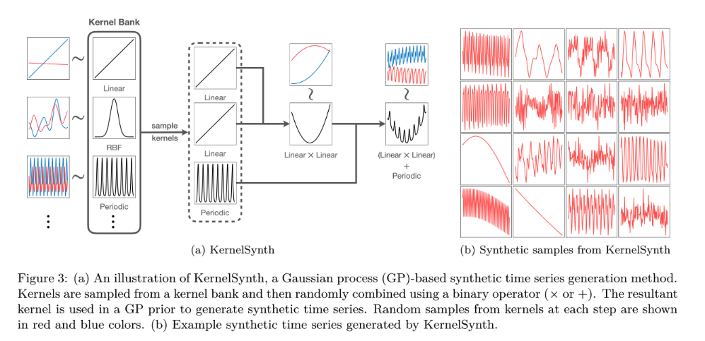

KernelSynth

## TSMixup

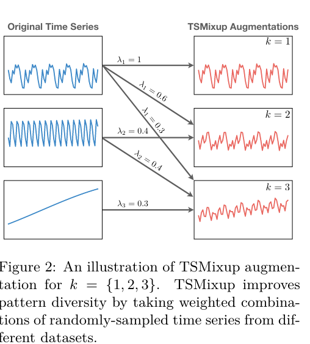

TSMixup

## Experimentos

Para entrenar a Chronos se incluye datasets públicos de: - Competencias desde la M hasta la M4. - Monash Time Series Forecasting Repository - Dataset de Kaggle

Estos dataset se dividierón en 3:

- Entrenamiento (13 datasets)
- Evaluación in-domain (15 datasets)
- Evaluación Zero-Shot (27 dataset)

En total 890K series de tiempo.

## Evaluación

#### MASE

$$MASE = \frac{\frac{1}{h} \sum_{t=1}^{h} |e_t|}{\frac{1}{T - m} \sum_{t=m+1}^{T} |y_t - y_{t-m}|}$$

Donde $m$ es el periodo estacional y $e_t$ es el error de predicción en el tiempo $t$. A valores más bajos mejor es el modelo, ya que si es 1 es igual a un modelo que predice igual que un modelo Naive y si es mayor a 1 es peor que un modelo que predice que un modelo Naive Estacional.

## Evaluación

#### WSQL

$$QL_{\alpha}(q,x) = \begin{cases}
\alpha (x-q) & \text{si } x > q \\
(1-\alpha)(q-x) & \text{si } en otro caso
\end{cases}$$

Para agregarla:

$$WQL_{\alpha} = \frac{2\sum_{i,t}{QL_{\alpha}(q_{i,t}^{(\alpha)},x_{i,t})}}{\sum_{i,t}{|x_{i,t}|}}$$

Y para realizar un promedio sobre una cantidad finita de cuantiles:

$$WQL = \frac{1}{K}\sum_{j=1}^{K}{WQL_{\alpha_{j}}}$$

## Resultados in-domain

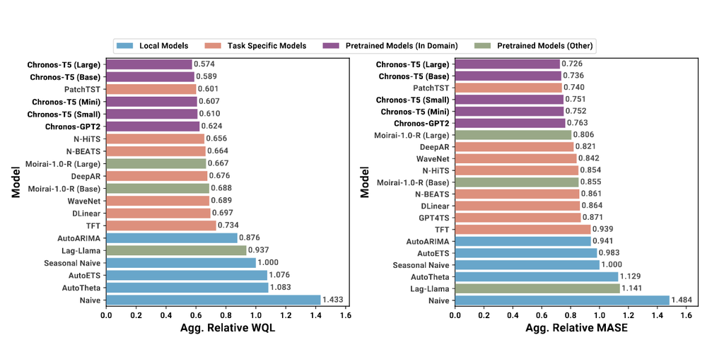

## Fine-Tune en T5 Small

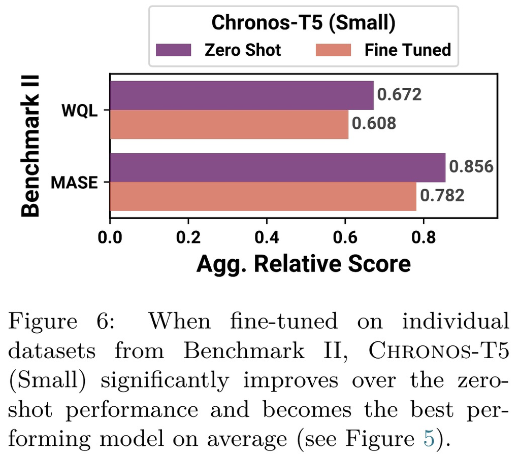

## Sobre el tamaño

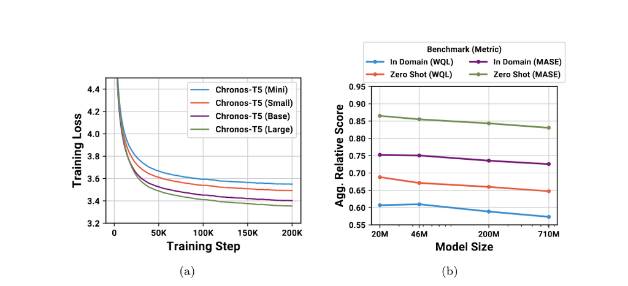

## Análisis de los hiperparámetros

- Tamaño del modelo: Aumentar el tamaño del modelo mejora el rendimiento. Aunque modelos chicos pueden ser suficientes para problemas sencillos con fine-tuning.
- Inicialización: Mejores resultados con pesos iniciados de forma aleatoria que eligiendo los de LLM.
- Datos sintéticos: Mejora el rendimiento, mas en su especificación mezclada TSMixup + KernelSynth.

## Análisis de los hiperparámetros

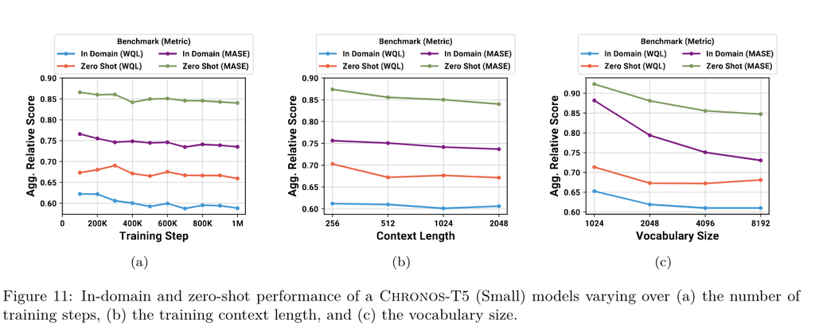

## Análisis Cualitativo

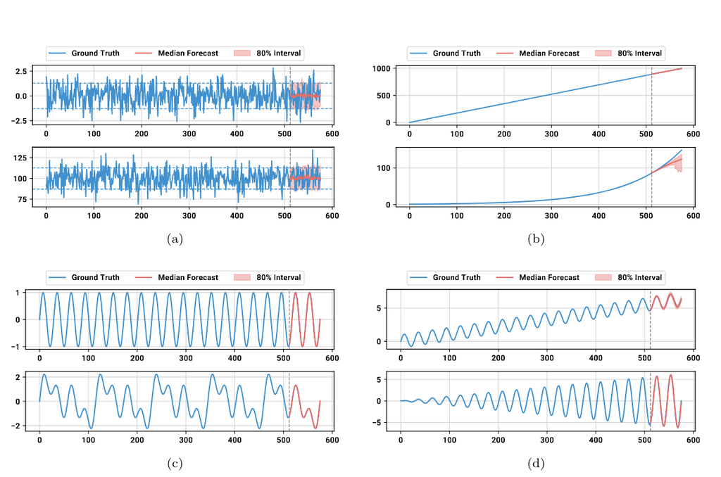

## Proceso de Inferencia

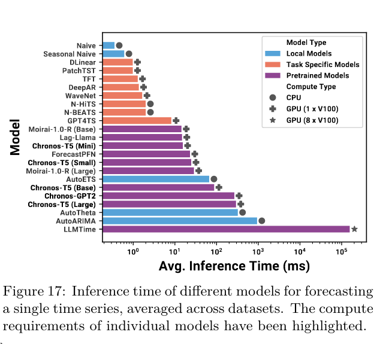

## Conclusiones

- Chornos demostró que la artiquitectura de LLM puede ser usada para modelar series de tiempo.
- Modelos de lenguaje grandes preentrenados pueden simplificar el proceso de modelado de series de tiempo sin sacrificar precisión, ofreciendo solo etapa de inferencia a la alternativa de entrenamiento y tuneo del modelo.

## Serie de pasajeros de aerolíneas

[interactive chart not shown]

## Datos M4

[figure not shown]